# DimensionalityReduction_se21m003_Goll_LargeDataset

```python
import pandas as pd
from pandas.api.types import CategoricalDtype
import matplotlib.pyplot as plt
from mpl_toolkits.mplot3d import Axes3D
import matplotlib as mpl
import numpy as np
import seaborn as sns

%matplotlib inline
```

```python
header_list = ["age","class of worker","detailed industry recode","detailed occupation recode","education","wage per hour","enroll in edu inst last wk","marital stat","major industry code","major occupation code","race","hispanic origin","sex","member of a labor union","reason for unemployment","full or part time employment stat","capital gains","capital losses","dividends from stocks","tax filer stat","region of previous residence","state of previous residence","detailed household and family stat","detailed household summary in household","instance weight","migration code-change in msa","migration code-change in reg","migration code-move within reg","live in this house 1 year ago","migration prev res in sunbelt","num persons worked for employer","family members under 18","country of birth father","country of birth mother","country of birth self","citizenship","own business or self employed","fill inc questionnaire for veteran's admin","veterans benefits","weeks worked in year","year","ignore"]
data = pd.read_csv('G:\My Drive\FH_Technikum\MSC\Semester_2_SS2022\DAS\DataVisualization\Data\CensusIncome\census-income.data', names=header_list)
data = data.drop(["ignore"], axis=1)
```

```python
data["education"] = data["education"].str.strip()

data["education_consolidated"] = data["education"].apply(lambda value: "lower" if value == "Children"
                                                                        or value == "7th and 8th grade"
                                                                        or value == "9th grade"
                                                                        or value == "10th grade"
                                                                        or value == "High school graduate"
                                                                        or value == "11th grade"
                                                                        or value == "12th grade no diploma"
                                                                        or value == "5th or 6th grade"
                                                                        or value == "Less than 1st grade"
                                                                        or value == "Some college but no degree"
                                                                    else "higher")
data["class of worker"] = pd.Categorical(data["class of worker"])
data["detailed industry recode"] = pd.Categorical(data["detailed industry recode"])
data["detailed occupation recode"] = pd.Categorical(data["detailed occupation recode"])
data["education"] = pd.Categorical(data["education"])
data["enroll in edu inst last wk"] = pd.Categorical(data["enroll in edu inst last wk"])
data["marital stat"] = pd.Categorical(data["marital stat"])
data["major industry code"] = pd.Categorical(data["major industry code"])
data["major occupation code"] = pd.Categorical(data["major occupation code"])
data["race"] = pd.Categorical(data["race"])
data["hispanic origin"] = pd.Categorical(data["hispanic origin"])
data["sex"] = pd.Categorical(data["sex"])
data["member of a labor union"] = pd.Categorical(data["member of a labor union"])
data["reason for unemployment"] = pd.Categorical(data["reason for unemployment"])
data["full or part time employment stat"] = pd.Categorical(data["full or part time employment stat"])
data["tax filer stat"] = pd.Categorical(data["tax filer stat"])
data["region of previous residence"] = pd.Categorical(data["region of previous residence"])
data["state of previous residence"] = pd.Categorical(data["state of previous residence"])
data["detailed household and family stat"] = pd.Categorical(data["detailed household and family stat"])
data["detailed household summary in household"] = pd.Categorical(data["detailed household summary in household"])
data["migration code-change in msa"] = pd.Categorical(data["migration code-change in msa"])
data["migration code-change in reg"] = pd.Categorical(data["migration code-change in reg"])
data["migration code-move within reg"] = pd.Categorical(data["migration code-move within reg"])
data["live in this house 1 year ago"] = pd.Categorical(data["live in this house 1 year ago"])
data["migration prev res in sunbelt"] = pd.Categorical(data["migration prev res in sunbelt"])
data["family members under 18"] = pd.Categorical(data["family members under 18"])
data["country of birth father"] = pd.Categorical(data["country of birth father"])
data["country of birth mother"] = pd.Categorical(data["country of birth mother"])
data["country of birth self"] = pd.Categorical(data["country of birth self"])
data["citizenship"] = pd.Categorical(data["citizenship"])
data["own business or self employed"] = pd.Categorical(data["own business or self employed"], ordered=True)
data["fill inc questionnaire for veteran's admin"] = pd.Categorical(data["fill inc questionnaire for veteran's admin"])
data["veterans benefits"] = pd.Categorical(data["veterans benefits"], ordered=True)
data["year"] = pd.Categorical(data["year"], ordered=True)

data.describe()
```

|  | age | wage per hour | capital gains | capital losses | dividends from stocks | instance weight | num persons worked for employer | weeks worked in year |
| --- | --- | --- | --- | --- | --- | --- | --- | --- |
| count | 199523.000000 | 199523.000000 | 199523.00000 | 199523.000000 | 199523.000000 | 199523.000000 | 199523.000000 | 199523.000000 |
| mean | 34.494199 | 55.426908 | 434.71899 | 37.313788 | 197.529533 | 1740.380269 | 1.956180 | 23.174897 |
| std | 22.310895 | 274.896454 | 4697.53128 | 271.896428 | 1984.163658 | 993.768156 | 2.365126 | 24.411488 |
| min | 0.000000 | 0.000000 | 0.00000 | 0.000000 | 0.000000 | 37.870000 | 0.000000 | 0.000000 |
| 25% | 15.000000 | 0.000000 | 0.00000 | 0.000000 | 0.000000 | 1061.615000 | 0.000000 | 0.000000 |
| 50% | 33.000000 | 0.000000 | 0.00000 | 0.000000 | 0.000000 | 1618.310000 | 1.000000 | 8.000000 |
| 75% | 50.000000 | 0.000000 | 0.00000 | 0.000000 | 0.000000 | 2188.610000 | 4.000000 | 52.000000 |
| max | 90.000000 | 9999.000000 | 99999.00000 | 4608.000000 | 99999.000000 | 18656.300000 | 6.000000 | 52.000000 |

```python
# data = data[data['wage per hour'] > 0]
data.describe()
```

|  | age | wage per hour | capital gains | capital losses | dividends from stocks | instance weight | num persons worked for employer | weeks worked in year |
| --- | --- | --- | --- | --- | --- | --- | --- | --- |
| count | 199523.000000 | 199523.000000 | 199523.00000 | 199523.000000 | 199523.000000 | 199523.000000 | 199523.000000 | 199523.000000 |
| mean | 34.494199 | 55.426908 | 434.71899 | 37.313788 | 197.529533 | 1740.380269 | 1.956180 | 23.174897 |
| std | 22.310895 | 274.896454 | 4697.53128 | 271.896428 | 1984.163658 | 993.768156 | 2.365126 | 24.411488 |
| min | 0.000000 | 0.000000 | 0.00000 | 0.000000 | 0.000000 | 37.870000 | 0.000000 | 0.000000 |
| 25% | 15.000000 | 0.000000 | 0.00000 | 0.000000 | 0.000000 | 1061.615000 | 0.000000 | 0.000000 |
| 50% | 33.000000 | 0.000000 | 0.00000 | 0.000000 | 0.000000 | 1618.310000 | 1.000000 | 8.000000 |
| 75% | 50.000000 | 0.000000 | 0.00000 | 0.000000 | 0.000000 | 2188.610000 | 4.000000 | 52.000000 |
| max | 90.000000 | 9999.000000 | 99999.00000 | 4608.000000 | 99999.000000 | 18656.300000 | 6.000000 | 52.000000 |

One could clean up data by removing all values of 0 for wage per hour or dividends from stock. However, this would decrease datapoints available for analysis.

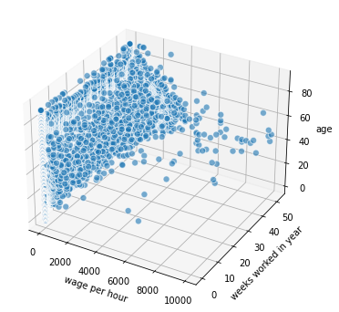

```python
fig = plt.figure(figsize=(8, 6))
ax = fig.add_subplot(111, projection='3d')

columns = ['wage per hour', 'weeks worked in year', 'age']

xs = data['wage per hour']
ys = data['weeks worked in year']
zs = data['age']
ax.scatter(xs, ys, zs, s=50, alpha=0.6, edgecolors='w')

ax.set_xlabel('wage per hour')
ax.set_ylabel('weeks worked in year')
ax.set_zlabel('age')
```

The plot shows a strong gathering of datapoints in the higher values of the 'weeks worked in year' dimension and lower values in the 'wage per hour' dimension. The more weeks are worked in a year, the higher the wage per hour seems to be. However, age does not seem to make much of a difference.

A large number of datapoints with wage per hour of 0 is present.

```python
subsample_data = data[['wage per hour', 'weeks worked in year', 'age']]
subsample_data.describe()
```

|  | wage per hour | weeks worked in year | age |
| --- | --- | --- | --- |
| count | 199523.000000 | 199523.000000 | 199523.000000 |
| mean | 55.426908 | 23.174897 | 34.494199 |
| std | 274.896454 | 24.411488 | 22.310895 |
| min | 0.000000 | 0.000000 | 0.000000 |
| 25% | 0.000000 | 0.000000 | 15.000000 |
| 50% | 0.000000 | 8.000000 | 33.000000 |
| 75% | 0.000000 | 52.000000 | 50.000000 |
| max | 9999.000000 | 52.000000 | 90.000000 |

Escpecially the mean (average) values for wage per hour seems to be a lot lower than the maximum. This indicates that most datapoints reside in the lower value range. This is not surprising, since a lot of datapoints have a 0 value for this variable. Weeks worked seems to be rather balanced. The age-range is wide and comprises values from 0 to 90.

### MDS

Using MDS on the large dataset (with the 0 values) resulted in the error: 'Unable to allocate 297. GiB for an array with shape (199523, 199523) and data type float64'. It is therefore to large for this method. I opted to filter the data according to the following code block:

```python
reduced_subsample_data = subsample_data[subsample_data['wage per hour'] > 0]
reduced_subsample_data = reduced_subsample_data[reduced_subsample_data['age'] > 18]
reduced_subsample_data = reduced_subsample_data[reduced_subsample_data['weeks worked in year'] > 30]
reduced_subsample_data.describe()
```

|  | wage per hour | weeks worked in year | age |
| --- | --- | --- | --- |
| count | 9380.000000 | 9380.000000 | 9380.000000 |
| mean | 1039.527612 | 50.328252 | 38.442111 |
| std | 658.023546 | 4.224966 | 12.335846 |
| min | 20.000000 | 31.000000 | 19.000000 |
| 25% | 648.000000 | 52.000000 | 29.000000 |
| 50% | 878.000000 | 52.000000 | 37.000000 |
| 75% | 1272.000000 | 52.000000 | 47.000000 |
| max | 9999.000000 | 52.000000 | 90.000000 |

Further reducing the amount of data after the prior description:

```python
reduced_subsample_data = reduced_subsample_data[reduced_subsample_data['wage per hour'] < 1272]
reduced_subsample_data = reduced_subsample_data[reduced_subsample_data['age'] > 18]
reduced_subsample_data = reduced_subsample_data[reduced_subsample_data['weeks worked in year'] > 30]
reduced_subsample_data.describe()
```

|  | wage per hour | weeks worked in year | age |
| --- | --- | --- | --- |
| count | 7032.000000 | 7032.000000 | 7032.000000 |
| mean | 771.359926 | 50.131968 | 37.319681 |
| std | 236.849900 | 4.412256 | 12.837404 |
| min | 20.000000 | 31.000000 | 19.000000 |
| 25% | 600.000000 | 52.000000 | 27.000000 |
| 50% | 750.000000 | 52.000000 | 35.000000 |
| 75% | 950.000000 | 52.000000 | 46.000000 |
| max | 1270.000000 | 52.000000 | 90.000000 |

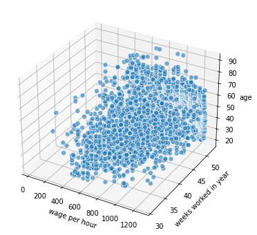

```python
fig = plt.figure(figsize=(8, 6))
ax = fig.add_subplot(111, projection='3d')

columns = ['wage per hour', 'weeks worked in year', 'age']

xs = reduced_subsample_data['wage per hour']
ys = reduced_subsample_data['weeks worked in year']
zs = reduced_subsample_data['age']
ax.scatter(xs, ys, zs, s=50, alpha=0.6, edgecolors='w')

ax.set_xlabel('wage per hour')
ax.set_ylabel('weeks worked in year')
ax.set_zlabel('age')
```

Here is the same plot as before but with the filtering applied.

```python
from sklearn.manifold import MDS
from sklearn.metrics import DistanceMetric

metric = DistanceMetric.get_metric('manhattan')
manhattan_data = metric.pairwise(reduced_subsample_data.values)

mds = MDS(n_components=2, max_iter=100, dissimilarity='precomputed', n_jobs=2, n_init=2)
mds_transformed = mds.fit_transform(reduced_subsample_data)
mds_transformed
```

```
array([[ 407.65224318,  133.20880685],
       [ 101.78091053,   25.41536206],
       [-250.97958079, -106.9200034 ],
       ...,
       [ 312.01650334,  103.83466225],
       [ 405.0568946 ,  124.54018669],
       [-147.59293724,  -52.06399449]])
```

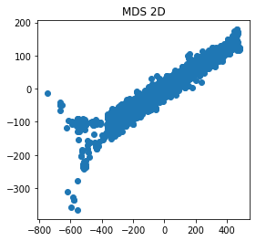

```python
fig_mds = plt.figure(2, (10,4))

ax_mds = fig_mds.add_subplot(122)
plt.scatter(mds_transformed[:,0], mds_transformed[:,1])
plt.title('MDS 2D')
fig_mds.subplots_adjust(wspace=.4, hspace=0.5)
plt.show()
```

### Isomap

One of the earliest approaches to manifold learning is the Isomap algorithm, short for Isometric Mapping. Isomap can be viewed as an extension of Multi-dimensional Scaling (MDS) or Kernel PCA. Isomap seeks a lower-dimensional embedding which maintains geodesic distances between all points. Isomap can be performed with the object Isomap. (Source: https://scikit-learn.org/stable/modules/manifold.html#isomap)

```python
from sklearn.manifold import Isomap
from scipy import sparse

sparse_data = sparse.csr_array(reduced_subsample_data.values)

isomap = Isomap(n_components=2, n_neighbors=100)
isomap_transformed = isomap.fit_transform(sparse_data)
isomap_transformed
```

```
array([[-429.2116919 ,    6.8991633 ],
       [-104.94264173,   10.09726598],
       [ 275.72144294,   16.45576485],
       ...,
       [-329.06741913,    5.32167077],
       [-424.22827975,    7.29543008],
       [ 157.4516285 ,    4.2410951 ]])
```

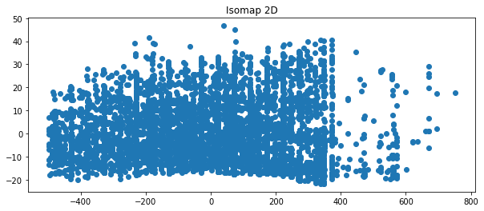

```python
fig_isomap = plt.figure(2, (10,4))

ax_isomap = fig.add_subplot(122)
plt.scatter(isomap_transformed[:,0], isomap_transformed[:,1])
plt.title('Isomap 2D')
fig_isomap.subplots_adjust(wspace=.4, hspace=0.5)
plt.show()
```

As with the 3-D plot, it can be observed that projected to a lower deimenstion while keeping the distance measure (geodesic distance in this case), the clumping remains. Since there was no discernable grouping in the 3-D plot, it can't be observed in a lower dimension either. However, the structure seems to thin out to the right probably due to the fact that in the 3-D plot there is also a concentration of datapoints in the higher value ranges of the dimension 'weeks worked in a year'.

### PCA

```python
subsample_data.describe()
```

|  | wage per hour | weeks worked in year | age |
| --- | --- | --- | --- |
| count | 199523.000000 | 199523.000000 | 199523.000000 |
| mean | 55.426908 | 23.174897 | 34.494199 |
| std | 274.896454 | 24.411488 | 22.310895 |
| min | 0.000000 | 0.000000 | 0.000000 |
| 25% | 0.000000 | 0.000000 | 15.000000 |
| 50% | 0.000000 | 8.000000 | 33.000000 |
| 75% | 0.000000 | 52.000000 | 50.000000 |
| max | 9999.000000 | 52.000000 | 90.000000 |

```python
from sklearn.decomposition import IncrementalPCA

pca = IncrementalPCA(n_components=2, batch_size=200)
pca_transformed = pca.fit_transform(subsample_data)
```

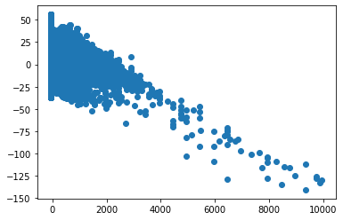

```python
plot = plt.scatter(pca_transformed[:,0], pca_transformed[:,1])
plt.show()
```

PCA can be done on the large dataset in a short time. This plot also shows a concentration of datapoints. This corresponds to the concentration of datapoints in the 3-D plot in the higher value range of the dimension 'weeks worked in a year'.

### t-SNE

```python
from sklearn.manifold import TSNE

tsne_transformed = TSNE(n_components=2, learning_rate='auto',
                   init='random').fit_transform(subsample_data.values)
```

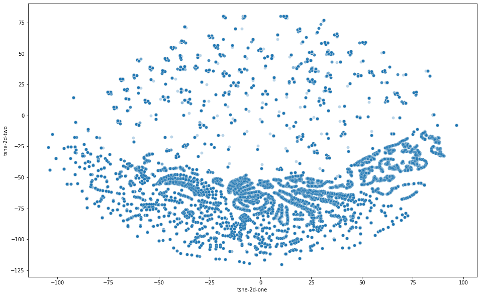

```python
df_subset = pd.DataFrame()
df_subset['tsne-2d-one'] = tsne_transformed[:,0]
df_subset['tsne-2d-two'] = tsne_transformed[:,1]

plt.figure(figsize=(16,10))
sns.scatterplot(
    x="tsne-2d-one", y="tsne-2d-two",
    palette=sns.color_palette("hls", 10),
    data=df_subset,
    legend="full",
    alpha=0.3
)
```

The plot of the result from the tsne-transformation is rather unexpected. But again, there seems to be a concentration of datapoints in the lower area of the plot corresponding to the concentration of datapoints in the higher value range of 'weeks worked in year'. Even though it is an irrelevant observation from a data science point of view, this plot seems to be the most beautiful. The dispersion is rather wide. Ther is considerably less clumping. Some unexpected patterns also emerged. These patterns can't be observed in the 3-D plot. T-SNE seems to tend to cluster the datapoints due to how it deals with similarities (moving points closer to similar points, similarity is based on probabilities instead of euclidean distances and therefore the euclidean distance is not preserved).